# Epigenetic and MZT Biomarker Expression

#### Log-transform the count data

First we are going to log-transform the data using a variance stabilizing transforamtion (VST). This is only for visualization purposes. Essentially, this is roughly similar to putting the data on the log2 scale. It will deal with the sampling variability of low counts by calculating within-group variability (if blind=FALSE). Importantly, it does not use the design to remove variation in the data, and so can be used to examine if there may be any variability do to technical factors such as extraction batch effects.

To do this we first need to calculate the size factors of our samples. This is a rough estimate of how many reads each sample contains compared to the others. In order to use VST (the faster log2 transforming process) to log-transform our data, the size factors need to be less than 4. Otherwise, there could be artefacts in our results.

```r
SF.gdds_dev <- estimateSizeFactors(gdds_dev) #estimate size factors to determine if we can use vst  to transform our data. Size factors should be less than for to use vst
print(sizeFactors(SF.gdds_dev)) #View size factors
```

```
##      X119      X120      X121      X127      X132      X153      X154      X159
## 1.0519967 0.5686680 0.7558557 0.5351080 0.5251546 1.0029584 1.8794576 0.7811492
##      X162      X163      X167      X179      X180      X184      X212      X215
## 1.5226504 1.7499897 1.7848493 1.0151292 0.8308898 0.9339607 1.1350398 0.8053938
##      X218      X221      X359      X361      X375     X1101     X1548     X1628
## 1.6504284 1.1560682 1.4281348 1.3679823 1.0904351 1.2882416 0.8315212 0.9180700
```

Our size factors are all less than 4, so we can use VST!

```r
gvst_dev <- vst(gdds_dev, blind=FALSE) #apply a variance stabilizing transforamtion to minimize effects of small counts and normalize wrt library size
head(assay(gvst_dev), 3) #view transformed gene count data
```

```
##            X119     X120     X121     X127     X132     X153     X154     X159
## g16981 8.873991 8.873991 9.127751 8.873991 8.873991 8.873991 8.873991 9.403881
## g16985 8.873991 8.873991 8.873991 8.873991 8.873991 8.873991 8.873991 8.873991
## g16984 8.873991 8.873991 8.873991 8.873991 8.873991 8.873991 8.873991 8.873991
##            X162     X163     X167     X179     X180     X184     X212     X215
## g16981 9.173980 9.125417 8.873991 9.129687 9.116050 9.224550 8.873991 8.873991
## g16985 8.873991 8.873991 8.873991 8.873991 8.873991 8.873991 8.873991 9.022359
## g16984 8.873991 8.873991 8.873991 8.873991 8.873991 8.873991 8.936504 8.873991
##            X218     X221     X359     X361     X375    X1101    X1548    X1628
## g16981 9.184462 9.079270 9.168398 9.174778 9.717659 9.521989 9.372258 9.796006
## g16985 8.873991 8.873991 9.096707 8.954515 9.075528 9.085384 8.947025 9.124311
## g16984 8.977659 8.981261 8.985432 9.086872 9.120722 9.303627 8.873991 8.873991
```

```r
#Make a list of observations
exp_df <- as.data.frame(assay(gvst_dev))
exp_list <- c(exp_df$X119, exp_df$X120, exp_df$X121, exp_df$X127, exp_df$X132, exp_df$X153, exp_df$X154, exp_df$X159, exp_df$X162, exp_df$X163, exp_df$X167, exp_df$X179, exp_df$X180, exp_df$X184, exp_df$X212, exp_df$X215, exp_df$X218, exp_df$X221, exp_df$X359, exp_df$X361, exp_df$X375, exp_df$X1101, exp_df$X1548, exp_df$X1628)
sanity.check <- nrow(exp_df)*ncol(exp_df) #make sure num observations match
length(exp_list) == sanity.check #make sure num observations match. Should be true.
```

```
## [1] TRUE
```

```r
#Get stats and view distribution as a histogram
max(exp_list)
```

```
## [1] 19.30772
```

```r
mean(exp_list)
```

```
## [1] 9.58362
```

```r
median(exp_list)
```

```
## [1] 9.223431
```

```r
min(exp_list)
```

```
## [1] 8.873991
```

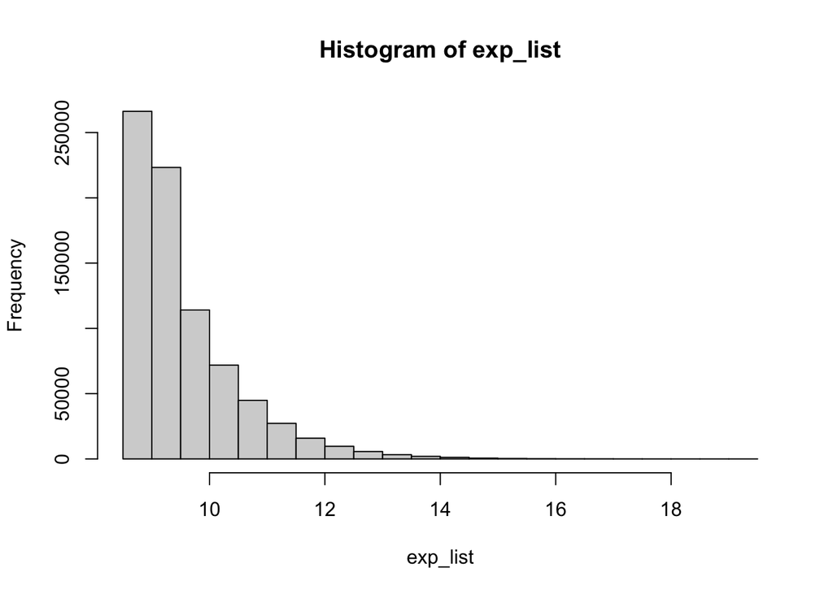

```r
hist(exp_list)
```